# INTRODUCTION

WeRateDogs is a Twitter account that rates people's dogs with a humorous comment about the dog. The account shares images of the dogs with a brief comment, then let their followers rate the dogs. These ratings almost always have a denominator of 10 with the numerator almost always above 10. For this project, WeRateDogs has downloaded their twitter archive, over 5000+ tweets which we'll be analysing. Also, Udacity ran every image in the WeRateDogs Twitter archive through a neural network that can classify breeds of dogs. Additional data from Twitter API including each tweet's retweet count and favourite(like) count. This project will including Wrangling acts and Analysing of the data. The dataset has metrics for measuring dog images. The analysis done will determine factors that influence tweet metrics.

### What characteristics of the dog influences tweet metrics?

Based on my analysis, the top 10 popular breeds are not the breeds with top ratings, retweet count and favorite count. Bouvier des flandres has the highest ratings, Saluki has the highest favorite count and Standard poodle has the highest retweet count. The top ratings, retweet count and favorite count show no relationship with breed popularity as breeds like Black-and-tan coonhound which falls under the least popular breeds has a high favorite count ranking 5th. Pupper which means a dog of younger age have less ratings and retweet and favorite count while the older dogs doggo have high ratings and favorite and retweet count.

**Top Breeds based on Average ratings**

```
                       ratings  favorite_count  retweet_count
breed
bouvier des flandres  1.300000    18032.000000    4479.000000
saluki                1.250000    24060.000000    5133.750000
tibetan mastiff       1.240000     9738.800000    5335.800000
briard                1.233333     9511.666667    2966.666667
border terrier        1.214286    13578.000000    3377.142857
silky terrier         1.200000     7317.000000    1891.000000
standard schnauzer    1.200000     2046.000000     928.000000
irish setter          1.183333     7054.500000    3302.833333
gordon setter         1.175000     5529.250000    2495.500000
samoyed               1.171739    12693.608696    5401.434783
```

**Top Breeds based on Average favorite_count**

```
                          ratings  favorite_count  retweet_count
breed
saluki                   1.250000    24060.000000    5133.750000
bedlington terrier       1.033333    21153.166667    7510.166667
bouvier des flandres     1.300000    18032.000000    4479.000000
french bulldog           1.128125    17841.281250    5273.375000
black-and-tan coonhound  1.050000    17012.000000    4164.500000
flat-coated retriever    1.087500    16791.625000    4520.250000
irish water spaniel      1.133333    16400.000000    4500.666667
leonberg                 1.133333    14934.333333    3863.666667
mexican hairless         0.985714    13590.571429    4254.857143
border terrier           1.214286    13578.000000    3377.142857
```

**Top Breeds based on Average retweet_count**

```
                     ratings  favorite_count  retweet_count
breed
standard poodle     1.100000    12753.416667    8568.833333
bedlington terrier  1.033333    21153.166667    7510.166667
afghan hound        1.050000    12995.000000    7162.750000
cocker spaniel      1.147059    11982.705882    6059.764706
samoyed             1.171739    12693.608696    5401.434783
tibetan mastiff     1.240000     9738.800000    5335.800000
french bulldog      1.128125    17841.281250    5273.375000
saluki              1.250000    24060.000000    5133.750000
english springer    1.045455    12853.000000    5106.272727
whippet             1.018182    12911.454545    4840.272727
```

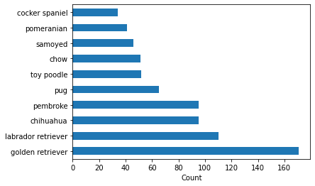

### What features of the tweet influences tweet metrics?

Wednesday have the highest favorite and retweet count, Tuesday although has the second highest retweet count has an average favorite count.Small text length get the highest ratings, while medium text length get the highest favorite and retweet count.

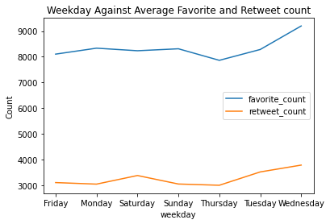

| source | ratings | favorite_count | retweet_count |
| --- | --- | --- | --- |
| Iphone | 1.092838 | 8412.746419 | 3261.774536 |
| TweetDeck | 1.100000 | 4911.222222 | 1753.777778 |
| Vine | 1.139560 | 7969.527473 | 3854.417582 |
| Web | 1.046154 | 5318.000000 | 2253.346154 |

# Conclusion

This project included the wrangling and analysis of WeRateDogs tweet. The aim of the analysis was to explore the dataset to provide insights on determining factor for good metrics ie high ratings, retweet and favorite counts. High ratings, retweet and favorite count showed no relation with dog breed popularity and with each other. Tweets with high ratings did not necessarily have high retweet and favorite count. Tweet with small text length and tweets made on Wednesday had the good metrics.